# Stat 323/523: Design and Analysis of Experiments I

Cal Poly - San Luis Obispo, Winter 2026

Author

Dr. Emily Robinson

## Communication

Email: erobin17@calpoly.edu

Office: Building 25 Office 103 (by Statistics Department Office)

**Discord Discussion Board:**

For questions of general interest, such as course clarifications or conceptual questions, please use the Discord page for discussion (join via Canvas). I encourage you to give your post a concise and informative post title/first sentence, so that other people can find it. For example, *“How do I determine the treatment structure?”* is a better title than *“help with activity 1”*.

While your posts are not anonymous, in this case there is no such thing as a bad question!

## Course Logistics

**Class Meeting Time:** Tuesday/Thursday

- Section 70 at 2:10 - 4:00pm
- Section 71 at 4:10 - 6:00pm

**Room:** Erhart Agriculture (Building 10-225)

**Office Hours** are held in my office (25-103) during the following times:

[video not shown]

Introducing Faculty Office Hours

| Day | Time |
| --- | --- |
| Tuesday | 9:30 - 11:00am |
| Thursday | 9:30 - 11:00am |

Note that office hours are not just for when you have content questions. Stop by to introduce yourself, ask questions about the broader field of statistics, or share what you are working on!

# Course Description

Stat 323/523 is designed to engage you in the principles, construction and analysis of experimental designs. Completely randomized, randomized complete block, Latin squares, Graeco Latin squares, factorial, and nested designs. Fixed and random effects, expected mean squares, multiple comparisons, and analysis of covariance.

**Prerequisites**: Entrance to STAT 323/523 requires completion of STAT 302.

# Learning Objectives

By the end of the course, you should:

- understand the single factor fixed effects model, and be able to carry out the analysis culminating in the F-test and appropriate multiple comparisons.
- understand the difference between fixed and random effects.
- understand the rationale behind the use of blocking, Latin squares, and other noise-reducing designs.
- be able to recognize different designs.
- be able to perform the statistical computations and express the results of the quantitative work through your writing skills.

# Course Materials & Tools

For each topic, you will prepare for class by watching 1-3 short lecture videos following a set of *lecture slide notes* containing definitions and examples. You are expected to either print or save the lecture slide notes to your device and follow along, filling out your set of notes while watching the videos.

During class, I will highlight any key points from the lecture videos and we will complete activities meant to reinforce the ideas learned in the videos.

Supplemental reading from [A First Course in Design and Analysis of Experiments](http://users.stat.umn.edu/%7Egary/book/fcdae.pdf) by Gary W. Oehlert will be recommended.

Tools and statistical software you will need for this course:

Laptop

Statistical software – R/RStudio or JMP

Gradescope – an app on your phone or computer browser

# Class Schedule & Topic Outline

This schedule is tentative and subject to change.

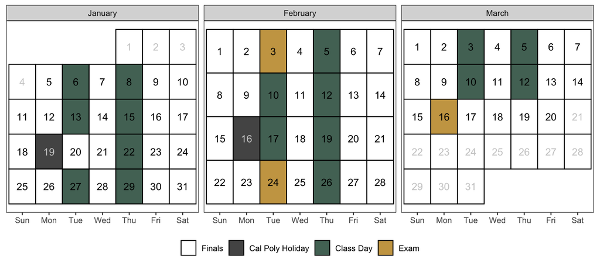

Note: Tuesday, January 20th follows a Monday schedule.

Tentative schedule of class topics:

| Date | Topic |
| --- | --- |
| Jan 6, Jan 8 | Module 1: Intro to Design of Experiments (DOE) |
| Jan 13, Jan 15 | Module 2: Completely Randomized Designs (CRD) |
| Jan 22 | Module 3: Power |
| Jan 27, Jan 29 | Module 4: Factorials |
| Feb 5 | Module 5: Randomized Complete Block Designs (RCBD) |
| Feb 3 | Midterm Exam 1 |
| Feb 10, Feb 12 | Module 6: Random Effects & Mixed Models |
| Feb 17, Feb 19 | Module 7: Extensions to Block Designs |
| Feb 26 | Module 8: Nonparametric Tests |
| Feb 24 | Midterm Exam 2 |
| Mar 3, Mar 5 | Final Project Worktime |
| Mar 10, Mar 12 | Final Project Presentations |
| Mar 16 | Common Final Exam |

# Course Policies

## Assessment/Grading

Your grade in STAT 323/523 will contain the following components:

| Category | Percent |
| --- | --- |
| Class Preparation, Participation, & Professionalism | 5% |
| In-class Activities | 10% |
| Island Labs | 15% |
| Final Project | 15% |
| Midterm Exam 1 | 17.5% |
| Midterm Exam 2 | 17.5% |
| Final Exam | 20% |

Lower bounds for grade cutoffs are shown in the following table. I will not “round up” grades at the end of the quarter. See this [thread](https://twitter.com/drseanmullen/status/1604212304622518272?s=46&t=II3oNLTSSrljVPqptoe21g) for advice on *“Playing the lines. Don’t be there.”*

> When my 11yo daughter complains her opponent in tennis is calling calls out..  
> I tell her:  
> “Don’t play the lines.”  
> As a college student, eventually every professor has to draw some lines.  
> Don’t play them so close. Don’t be there.

> — Dr. Sean Mullen (@drseanmullen) [December 17, 2022](https://twitter.com/drseanmullen/status/1604212307260645376?ref_src=twsrc%5Etfw)

| Letter grade | X + | X | X - |
| --- | --- | --- | --- |
| A | . | 93 | 90 |
| B | 87 | 83 | 80 |
| C | 77 | 73 | 70 |
| D | 67 | 63 | 60 |
| F | <60 |  |  |

Interpretation of this table:

- A grade of 85 will receive a B.
- A grade of 77 will receive a C+.
- A grade of 70 will receive a C-.
- Anything below a 60 will receive an F.

### General Evaluation Criteria

In every assignment, discussion, and written component of this class, you are expected to demonstrate that you are intellectually engaging with the material. I will evaluate you based on this engagement, which means that technically correct but low effort answers which do not demonstrate engagement or understanding will receive no credit.

While this is not an English class, grammar and spelling are important, as is your ability to communicate technical information in writing; both of these criteria will be used in addition to assignment-specific rubrics to evaluate your work.

## Assignment Breakdown

### Class Preparation, Participation, & Professionalism

This course uses a flipped classroom model. Core content is introduced before class through assigned videos or readings, and class time is devoted to activities and practice. Coming to class prepared is essential for your own learning and for your group’s success. Preparation may occasionally be checked using short, closed-note *learning quizzes* or *entry/exit tickets*

Participation credit is earned by being present, prepared, and engaged during class. You must be in class to receive participation credit. Part of this grade also reflects professionalism, including arriving on time, being mentally present, treating others with respect, and contributing constructively to group work.

- **2** participation grades will be dropped; think of these as “sick days”.

**Note**

If you are feeling ill, please *do not come to class*. You do not need to notify me, but instead do your best to complete the in-class activity found on Canvas. Then check with a group member anything missed in class. Stop by office hours after you are feeling better if you have any questions.

### In-class Activities

Most class meetings will include in-class activities designed to reinforce and apply course content. Class time will be dedicated to working on these activities. You may collaborate with your group members; however, each student must submit their own original work.

**Note**

Cal Poly provides access to [Gradescope](https://www.gradescope.com/). This course will use Gradescope for the first time this quarter, and we will work through the process together as needed.

### Lab Reports

You will complete 4 lab assignments in groups of 3-4. Each lab will involve designing a study and collecting data, often using [The Islands](https://islands.smp.uq.edu.au/). A written report summarizing your methods and findings will be submitted for each lab. More details will be provided in class.

- One report per group should be submitted as a PDF on Canvas.
- Lab reports are tentatively due on **Thursdays at 11:59 PM**.

### Final Project

You will complete a paired final project in which you design and propose an experiment, including all necessary details. The project will culminate in a 10-minute presentation during Week 10 of the quarter. Additional details and expectations will be provided later in the term.

### Exams

There will be two midterm exams and a final exam, designed to assess your individual understanding and progress in the course. You may bring a one-sided notesheet to each midterm exams and a two-sided notesheet to the final exam. Exam dates are listed in the course calendar. If you are unable to attend an exam, you must **notify me in advance.**

## Late Policy

We are living through a challenging time with unique, unusual circumstances. I do not want class deadlines to cause you extreme stress or anxiety. I offer **3 “grace days”** – 24 hours to turn in the assignment late without a penalty. These can be used on the in-class activities and lab assignments (a single group member must be willing to use one of their grace days for the entire group), but not participation, exams, or final project presentations. These “grace days” can be stacked and used all at once on a single assignment or spread out and used on separate assignments throughout the quarter. Simply send me an email to let me know you how many “grace days” you want to use on the assignment.

After using up your “grace days”, late work will be accepted with a 20% grade penalty for each day late (including weekends).

**WarningAutomatic Canvas Settings**

Canvas is set up to automatically input 0% for missing assignments (as an incentive to go complete the assignment) and apply the 20% grade deduction policy. I will need to manually adjust your grade when you use your grace days so it is important for you to leave a note on your assignment and email me. You are responsible for double checking your grade.

If you find yourself with extenuating circumstances beyond the defined late policy, please email me before the due date.

# Course Expectations

You will get out of this course what you put in. The following excerpt was taken from Rob Jenkins’ article “Defining the Relationship” which was published in The Chronicle of Higher Education (August 8, 2016). This accurately summarizes what I expect of you in my classroom (and also what you should expect of me).

*“I’d like to be your partner. More than anything, I’d like for us to form a mutually beneficial alliance in this endeavor we call education.*

*I pledge to do my part. I will:*

- *Stay abreast of the latest ideas in my field.*
- *Teach you what I believe you need to know; with all the enthusiasm I possess.*
- *Invite your comments and questions and respond constructively.*
- *Make myself available to you outside of class (within reason).*
- *Evaluate your work carefully and return it promptly with feedback.*
- *Be as fair, respectful, and understanding as I can humanly be.*
- *If you need help beyond the scope of this course, I will do my best to provide it or see that you get it.*

*In return, I expect you to:*

- *Show up for class each day or let me know (preferably in advance) if you have some good reason to be absent.*
- *Do your reading and other assignments outside of class and be prepared for each class meeting.*
- *Focus during class on the work we’re doing and not on extraneous matters (like whoever or whatever is on your phone at the moment).*
- *Participate in class discussions.*
- *Be respectful of your fellow students and their points of view.*
- *In short, I expect you to devote as much effort to learning as I devote to teaching.*

*What you get out of this relationship is that you’ll be better equipped to succeed in this and other college courses, work-related assignments, and life in general. What I get is a great deal of professional and personal satisfaction. Because I do really like you [all] and want the best for you.”*

# Learning Environment and Support

I am committed to creating a safe and inclusive learning environment where all students feel respected and supported. If there are any ways I can improve the classroom environment to make it more welcoming for you, please don’t hesitate to let me know.

If you have a disability and require accommodations to fully participate in the course, please contact me as soon as possible to discuss how I can best support you. I also encourage you to register with Cal Poly’s Disability Resource Center (Building 124, Room 119 or at 805-756-1395) to explore additional accommodations that may be available to you.

If you are experiencing food insecurity, housing instability, or other challenges that may impact your ability to succeed in this course, please refer to the resources listed on Canvas under “Student Support Services at Cal Poly.” These resources provide a range of essential support services, including emergency financial assistance, counseling, and academic support.

I am committed to working with you to ensure that you have the resources and support you need to succeed in this course. Let’s work together to create a positive and inclusive learning environment for all students.

# Academic Integrity and Class Conduct

Academic integrity is a fundamental value of this course and of the university. Simply put, I will not tolerate cheating, plagiarism, or any other form of academic dishonesty.

Any incident of academic misconduct, including dishonesty, copying, or plagiarism, will be reported to the Office of Student Rights and Responsibilities.

Cheating will earn you a grade of 0 on the assignment and an overall grade penalty of at least 10%. In circumstances of flagrant cheating, you may be given a grade of F in the course.

It is important to note that paraphrasing or quoting another’s work without proper citation is a form of academic misconduct. This includes using Chat GPT, which should only be used to generate ideas, provide feedback suggestions to improve your lab reports, and not as a substitute for your own work and writing. See more details below.

To ensure academic integrity, please be sure to cite all sources appropriately and only use Chat GPT in an ethical manner. For more information on academic misconduct and what constitutes cheating and plagiarism, please see academicprograms.calpoly.edu/content/academicpolicies/Cheating.

# ChatGPT

Use AI as a glorified tutor, not a ghostwriter. In this course, the value of AI tools is in helping you learn, practice, and clarify. They are not meant to produce work for you. Interpretation and critical thinking are important and simply copying AI output will not meet expectations and may constitute academic misconduct.

**What’s encouraged:**

- Concept help & explanations: Ask AI to re-explain ideas in plain language, give alternative examples, or break down statistical terms.
- R support: Use AI to clarify error messages, suggest functions, or outline strategies. Always run, test, and annotate the code yourself.
- Feedback on your work: Ask AI to critique your draft code or writing for clarity, not to write an introduction for you.

**What’s not allowed:**

- No AI-written answers submitted as your own. Interpretation is your responsibility.
- No copying/pasting code or text without understanding. Code can fail silently or even introduce harmful commands. You should always understand and adapt before running anything.
- No quiz use. In-person quizzes are closed note/book, and AI is prohibited.
- No uncredited use. Any substantive AI assistance must be disclosed (see below).

**CSU System Policy**

Cal Poly and all CSU campuses have access to ChatGPT Edu, provided through the CSU system. This version:

- Provides advanced AI capabilities tailored for CSU students and employees.
- Includes privacy, security, and data protections (similar to email, Google Workspace, and Microsoft 365).
- Offers single sign-on (SSO) and campus workspaces for sharing.
- Protects confidentiality, though CSU has legal/operational obligations that may require access to user data. These activities are not intended to monitor legitimate academic use.

For details, see:

- [CSU Safe and Responsible Use Guidelines](https://genai.calstate.edu/guidelines-safe-and-responsible-use-generative-ai-tools)
- [CSU Student Community Resources](https://genai.calstate.edu/communities/students)

**Your responsibilities:**

- Think critically. If you can’t explain a result in your own words, you don’t understand it.
- Demonstrate engagement. Work that is technically correct but shows no reasoning or interpretation will not receive full credit.
- Acknowledge *extensive* AI use. At the end of any assignment where you used AI, include a brief disclosure. Example:

> AI assistance: Consulted ChatGPT for debugging the `lm()` function syntax and clarifying the difference between a CRD and RCBD.

**Reminder:** In-person exams and verbal presentations exist for a reason. This class emphasizes your connection of research questions to experimental designs and statistical interpretations.